# Project about Pokemon Analysis

鼠八拉西隊

2020/6/14

## Introduction

- Motivation/Questions
- Data Preprocessing & View
- Result: Analysis and Findings
- Conclusion and Discussion

## Motivation/Questions

- 陪伴著我們長大的寶可夢，到現在熱潮依舊不減，  
  越來越多人陷入寶可夢的魅力中，  
  但好像沒有好好深入了解過，所以想透過這次的Project更認識他們
- 寶可夢戰鬥是我們有興趣研究的東西，我們想預測戰鬥勝利的寶可夢  
  所以我們透過機器學習的方法分析

```
##        X.            Name              Type.1             Type.2
##  Min.   :  1.0   Length:800         Length:800         Length:800
##  1st Qu.:200.8   Class :character   Class :character   Class :character
##  Median :400.5   Mode  :character   Mode  :character   Mode  :character
##  Mean   :400.5
##  3rd Qu.:600.2
##  Max.   :800.0
##        HP             Attack       Defense          Sp..Atk
##  Min.   :  1.00   Min.   :  5   Min.   :  5.00   Min.   : 10.00
##  1st Qu.: 50.00   1st Qu.: 55   1st Qu.: 50.00   1st Qu.: 49.75
##  Median : 65.00   Median : 75   Median : 70.00   Median : 65.00
##  Mean   : 69.26   Mean   : 79   Mean   : 73.84   Mean   : 72.82
##  3rd Qu.: 80.00   3rd Qu.:100   3rd Qu.: 90.00   3rd Qu.: 95.00
##  Max.   :255.00   Max.   :190   Max.   :230.00   Max.   :194.00
##     Sp..Def          Speed          Generation    Legendary
##  Min.   : 20.0   Min.   :  5.00   Min.   :1.000   Mode :logical
##  1st Qu.: 50.0   1st Qu.: 45.00   1st Qu.:2.000   FALSE:735
##  Median : 70.0   Median : 65.00   Median :3.000   TRUE :65
##  Mean   : 71.9   Mean   : 68.28   Mean   :3.324
##  3rd Qu.: 90.0   3rd Qu.: 90.00   3rd Qu.:5.000
##  Max.   :230.0   Max.   :180.00   Max.   :6.000
```

## 寶可夢18個種族平均戰力

[figure not shown]

## 把龍族跟蟲族拉出來看

Dragon

```
##      X.                Name Type.1   Type.2  HP Attack Defense Sp..Atk Sp..Def
## 160 160             Dratini Dragon           41     64      45      50      50
## 161 161           Dragonair Dragon           61     84      65      70      70
## 162 162           Dragonite Dragon   Flying  91    134      95     100     100
## 366 366             Altaria Dragon   Flying  75     70      90      70     105
## 367 367        Mega Altaria Dragon    Fairy  75    110     110     110     105
## 407 407               Bagon Dragon           45     75      60      40      30
## 408 408             Shelgon Dragon           65     95     100      60      50
## 409 409           Salamence Dragon   Flying  95    135      80     110      80
## 410 410      Mega Salamence Dragon   Flying  95    145     130     120      90
## 418 418              Latias Dragon  Psychic  80     80      90     110     130
## 419 419         Mega Latias Dragon  Psychic  80    100     120     140     150
## 420 420              Latios Dragon  Psychic  80     90      80     130     110
## 421 421         Mega Latios Dragon  Psychic  80    130     100     160     120
## 426 426            Rayquaza Dragon   Flying 105    150      90     150      90
```

[output cut: 51 more lines]

Bug

```
##      X.                 Name Type.1   Type.2 HP Attack Defense Sp..Atk Sp..Def
## 14   14             Caterpie    Bug          45     30      35      20      20
## 15   15              Metapod    Bug          50     20      55      25      25
## 16   16           Butterfree    Bug   Flying 60     45      50      90      80
## 17   17               Weedle    Bug   Poison 40     35      30      20      20
## 18   18               Kakuna    Bug   Poison 45     25      50      25      25
## 19   19             Beedrill    Bug   Poison 65     90      40      45      80
## 20   20        Mega Beedrill    Bug   Poison 65    150      40      15      80
## 52   52                Paras    Bug    Grass 35     70      55      45      55
## 53   53             Parasect    Bug    Grass 60     95      80      60      80
## 54   54              Venonat    Bug   Poison 60     55      50      40      55
## 55   55             Venomoth    Bug   Poison 70     65      60      90      75
## 133 133              Scyther    Bug   Flying 70    110      80      55      80
## 137 137               Pinsir    Bug          65    125     100      55      70
## 138 138          Mega Pinsir    Bug   Flying 65    155     120      65      90
```

[output cut: 125 more lines]

## 寶可夢傳說級&非傳說級分布

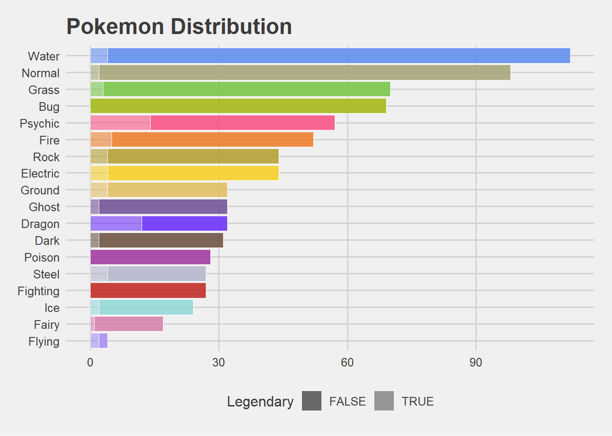

## 寶可夢種族數量

```r
# Type.1 pokemons
pokemon %>% group_by(Type.1) %>% summarise(Total_pokemon=n())%>% data.frame()
```

```
##      Type.1 Total_pokemon
## 1       Bug            69
## 2      Dark            31
## 3    Dragon            32
## 4  Electric            44
## 5     Fairy            17
## 6  Fighting            27
## 7      Fire            52
## 8    Flying             4
## 9     Ghost            32
## 10    Grass            70
## 11   Ground            32
## 12      Ice            24
## 13   Normal            98
## 14   Poison            28
## 15  Psychic            57
## 16     Rock            44
## 17    Steel            27
## 18    Water           112
```

```r
# Type.2 pokemons
pokemon %>% group_by(Type.2) %>% summarise(Total_pokemon=n())%>% data.frame()
```

```
##      Type.2 Total_pokemon
## 1                     386
## 2       Bug             3
## 3      Dark            20
## 4    Dragon            18
## 5  Electric             6
## 6     Fairy            23
## 7  Fighting            26
## 8      Fire            12
## 9    Flying            97
## 10    Ghost            14
## 11    Grass            25
## 12   Ground            35
## 13      Ice            14
## 14   Normal             4
## 15   Poison            34
## 16  Psychic            33
## 17     Rock            14
## 18    Steel            22
## 19    Water            14
```

```r
# Total number of pokemons by generations
pokemon %>% group_by(Generation) %>% summarise(Total_pokemon=n())%>% data.frame()
```

```
##   Generation Total_pokemon
## 1          1           166
## 2          2           106
## 3          3           160
## 4          4           121
## 5          5           165
## 6          6            82
```

## HP & Speed前十名的寶可夢

```r
# Top 10 pokemon with high hp
pokemon %>% group_by(Name,HP)%>% arrange(desc(HP)) %>% ungroup()  %>%
  select("Name","Type.1","HP")%>%head(10)%>% data.frame()
```

```
##                      Name  Type.1  HP
## 1                 Blissey  Normal 255
## 2                 Chansey  Normal 250
## 3               Wobbuffet Psychic 190
## 4                 Wailord   Water 170
## 5               Alomomola   Water 165
## 6                 Snorlax  Normal 160
## 7                 Slaking  Normal 150
## 8                Drifblim   Ghost 150
## 9  Giratina Altered Forme   Ghost 150
## 10  Giratina Origin Forme   Ghost 150
```

```r
# Top 10 pokemon with high speed
pokemon %>% group_by(Name,Speed)%>% arrange(desc(Speed)) %>% ungroup()  %>%
  select("Name","Type.1","Speed")%>%head(10)%>% data.frame()
```

```
##                   Name   Type.1 Speed
## 1   Deoxys Speed Forme  Psychic   180
## 2              Ninjask      Bug   160
## 3        Mega Alakazam  Psychic   150
## 4      Mega Aerodactyl     Rock   150
## 5  Deoxys Normal Forme  Psychic   150
## 6   DeoxysAttack Forme  Psychic   150
## 7        Mega Beedrill      Bug   145
## 8        Mega Sceptile    Grass   145
## 9             Accelgor      Bug   145
## 10           Electrode Electric   140
```

## 長條圖 &分布

HP

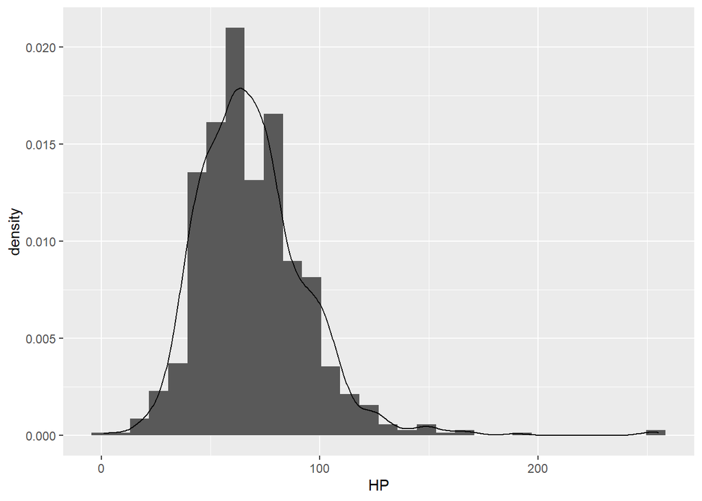

```r
ggplot(pokemon) +
  geom_histogram(bins = 30,aes(x=HP,y=..density..), position="identity") +
  geom_density(aes(x=HP,y=..density..))
```

Attack

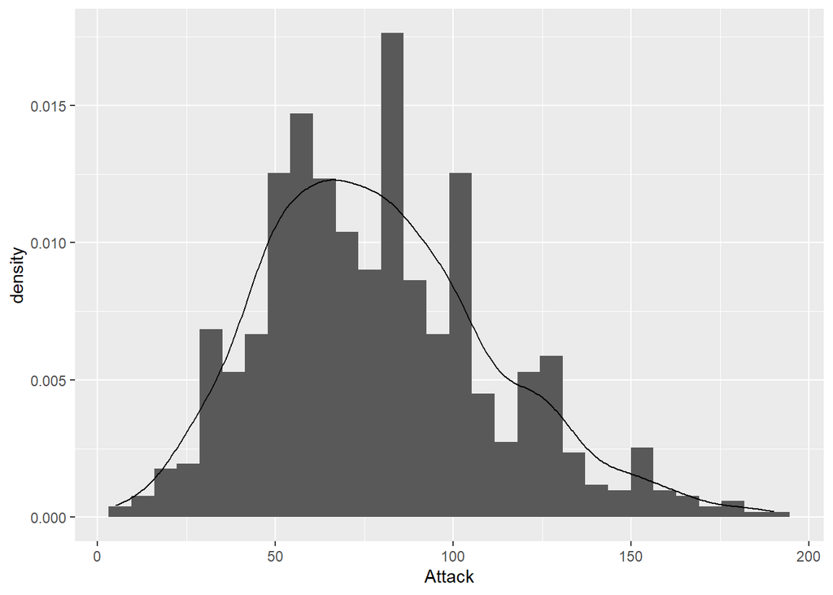

```r
ggplot(pokemon) +
  geom_histogram(bins = 30,aes(x=Attack,y=..density..), position="identity") +
  geom_density(aes(x=Attack,y=..density..))
```

Defense

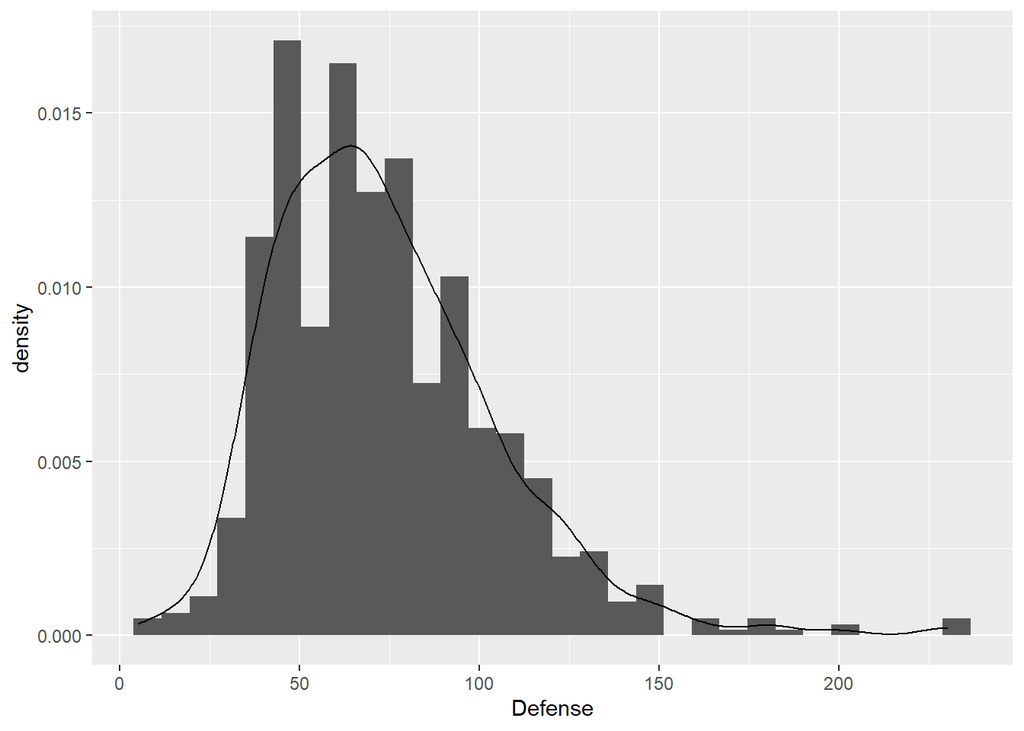

```r
ggplot(pokemon) +
  geom_histogram(bins = 30,aes(x=Defense,y=..density..), position="identity") +
  geom_density(aes(x=Defense,y=..density..))
```

Sp Atk

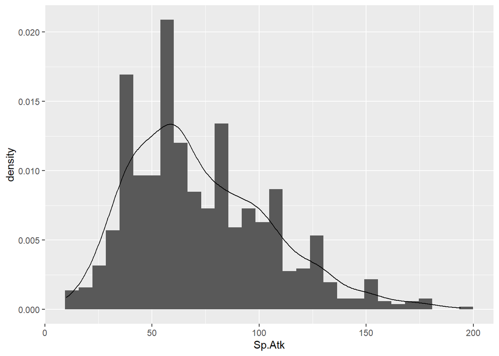

```r
ggplot(pokemon) +
  geom_histogram(bins = 30,aes(x=Sp.Atk,y=..density..), position="identity") +
  geom_density(aes(x=Sp.Atk,y=..density..))
```

SpDef

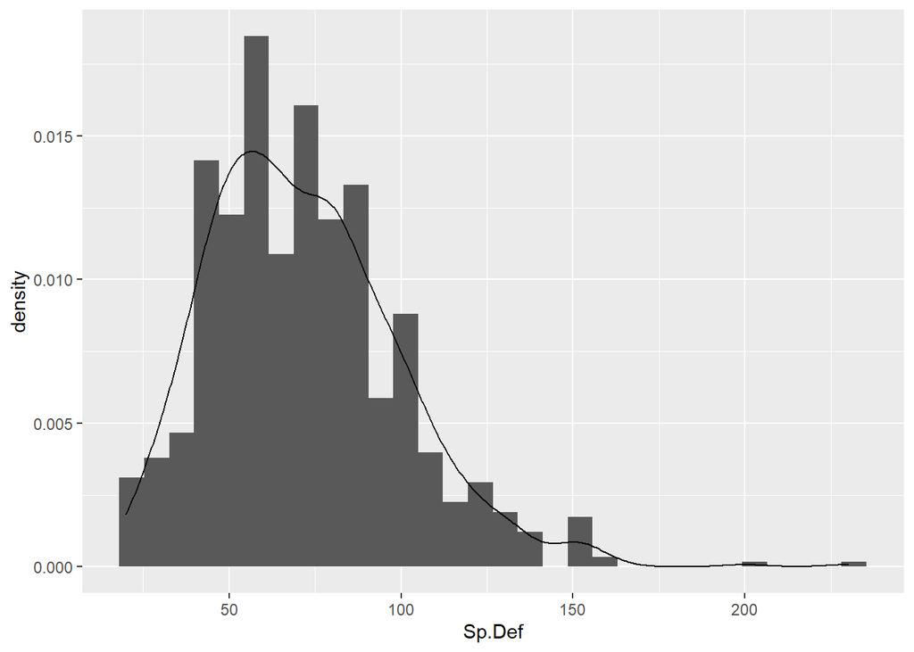

```r
ggplot(pokemon) +
  geom_histogram(bins = 30,aes(x=Sp.Def,y=..density..), position="identity") +
  geom_density(aes(x=Sp.Def,y=..density..))
```

Speed

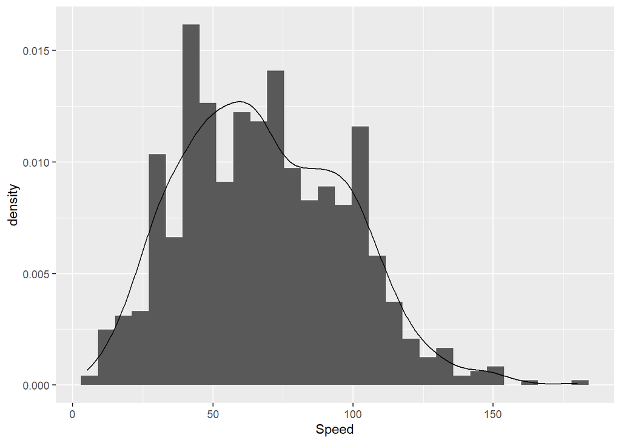

```r
ggplot(pokemon) +
  geom_histogram(bins = 30,aes(x=Speed,y=..density..), position="identity") +
  geom_density(aes(x=Speed,y=..density..))
```

```r
# hist(pokemon$HP,col = "red",freq = F,xlab = "HP",main = "HP")
# hist(pokemon$Attack,col = "gray",freq = F,xlab = "Attack",main = "Attack")
# hist(pokemon$Defence,col = "blue",freq = F,xlab = "Defence",main = "Defence")
# hist(pokemon$Sp.Atk,col = "green",freq = F,xlab = "Sp.Atk",main = "Sp.Atk")
# hist(pokemon$Sp.Def,col = "purple",freq = F,xlab = "Sp.Def",main = "Sp.Def")
# hist(pokemon$Speed,col = "yellow",freq = F,xlab = "Speed",main = "Speed")
```

## Pair

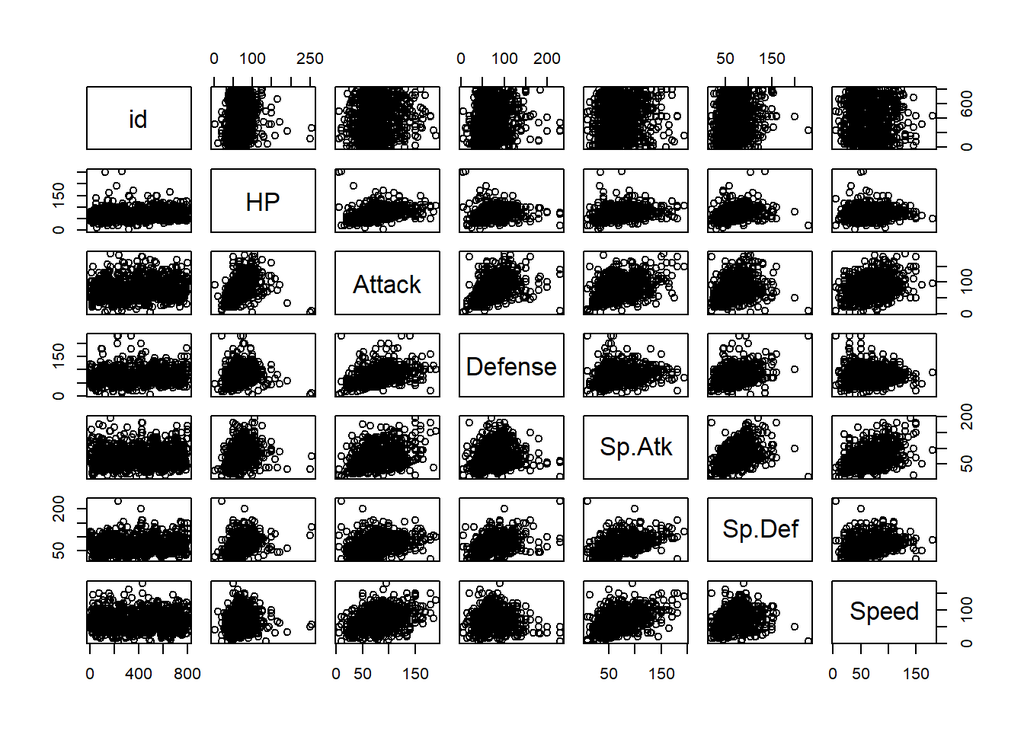

```r
n <- setdiff(names(pokemon), c("Name", "X.", "Type.1", "Type.2", "Legendary", "Generation"))
temp <- pokemon[n]
pairs(temp)
```

## 放大看Attack vs Defense 的關係

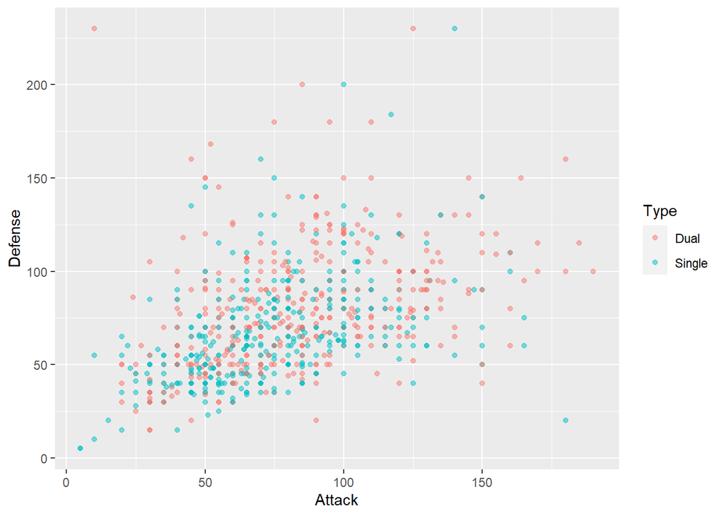

special attack vs special defens

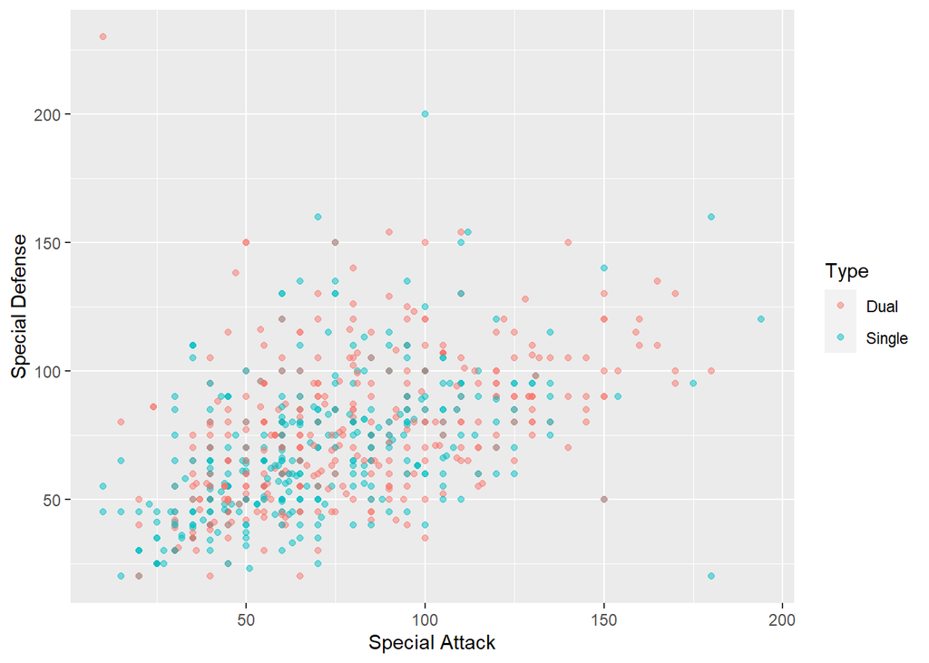

## MDS

```r
hchart(mds,"scatter", hcaes(x = X1,y = X2, group = pokemon$Type.1))
```

[interactive chart not shown]

[interactive chart not shown]

[figure not shown]

[figure not shown]

[figure not shown]

```r
hchart(mds,"scatter",hcaes(x=X1,y=X2,group=xx))
```

## pokemon戰鬥預測

```r
str(pokefight)
```

```
## 'data.frame':    50000 obs. of  26 variables:
##  $ First_pokemon : int  266 702 191 237 151 657 192 73 220 302 ...
##  $ Second_pokemon: int  298 701 668 683 231 752 134 545 763 31 ...
##  $ Winner        : int  298 701 668 683 151 657 134 545 763 31 ...
##  $ ID_1          : int  266 702 191 237 151 657 192 73 220 302 ...
##  $ Type1_1       : chr  "Rock" "Grass" "Fairy" "Fire" ...
##  $ Type2_1       : chr  "Ground" "Fighting" "Flying" "" ...
##  $ HP_1          : int  50 91 55 40 70 50 40 70 50 40 ...
##  $ Attack_1      : int  64 90 40 40 60 47 50 80 65 30 ...
##  $ Defense_1     : int  50 72 85 40 125 50 45 50 90 30 ...
##  $ Sp.Atk_1      : int  45 90 80 70 115 57 70 35 35 55 ...
##  $ Sp.Def_1      : int  50 129 105 40 70 50 45 35 35 30 ...
##  $ Speed_1       : int  41 108 40 20 55 65 70 35 15 85 ...
##  $ Generation_1  : Factor w/ 6 levels "1","2","3","4",..: 2 5 2 2 1 5 2 1 2 3 ...
##  $ Legendary_1   : logi  FALSE TRUE FALSE FALSE FALSE FALSE ...
##  $ ID_2          : int  298 701 668 683 231 752 134 545 763 31 ...
##  $ Type1_2       : chr  "Grass" "Rock" "Psychic" "Dragon" ...
##  $ Type2_2       : chr  "Dark" "Fighting" "" "" ...
##  $ HP_2          : int  70 91 75 77 20 60 65 150 50 35 ...
##  $ Attack_2      : int  70 129 75 120 10 50 50 100 53 55 ...
##  $ Defense_2     : int  40 90 75 90 230 150 35 120 62 40 ...
##  $ Sp.Atk_2      : int  60 72 125 60 10 50 115 100 58 50 ...
##  $ Sp.Def_2      : int  40 90 95 90 230 150 95 120 63 50 ...
##  $ Speed_2       : int  60 108 40 48 5 60 95 90 44 90 ...
##  $ Generation_2  : Factor w/ 6 levels "1","2","3","4",..: 3 5 5 5 2 6 1 4 6 1 ...
##  $ Legendary_2   : logi  FALSE TRUE FALSE FALSE FALSE FALSE ...
##  $ Result        : Factor w/ 2 levels "Loss","Win": 1 1 1 1 2 2 1 1 1 1 ...
```

## 速度是怎麼影響寶可夢的戰鬥?

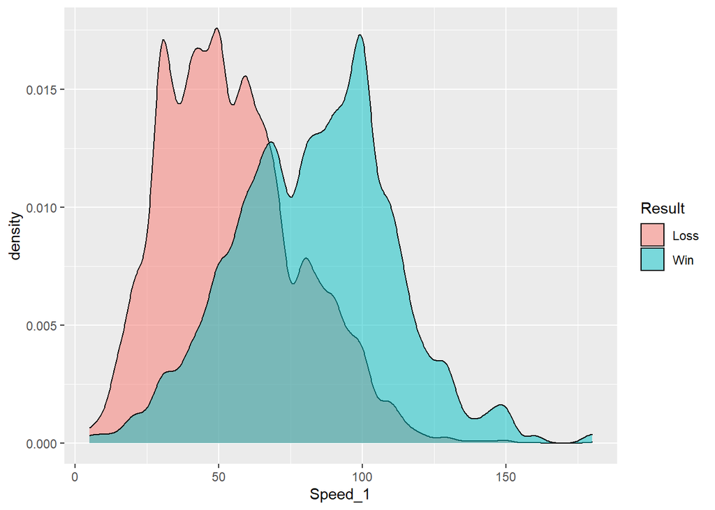

```r
ggplot(pokefight, aes(Speed_1, fill = Result)) + geom_density(alpha = 0.5)
```

## 傳說級寶可夢的速度有沒有比非傳說級的快?

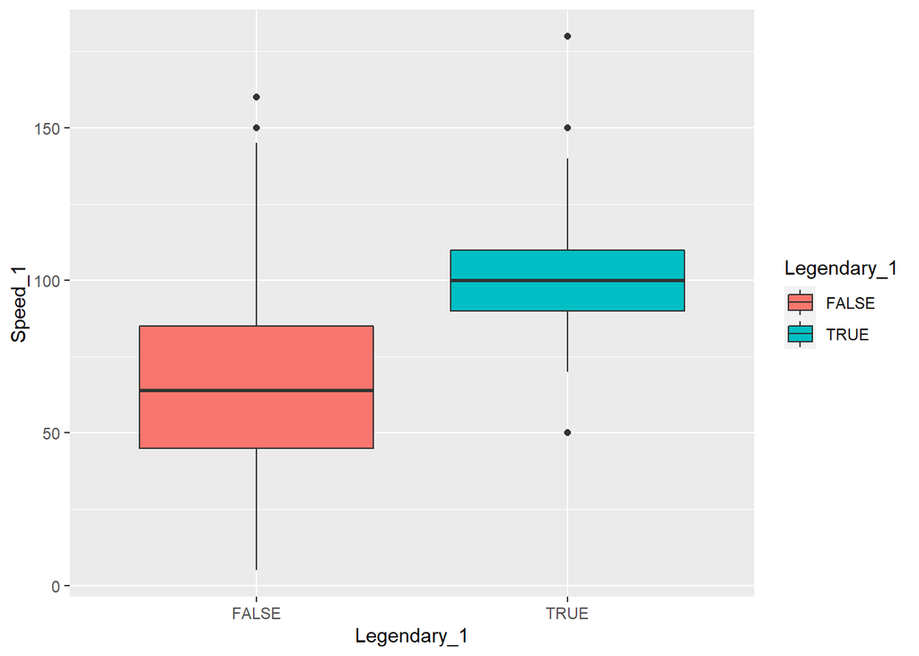

```r
ggplot(pokefight, aes(Legendary_1, Speed_1,  fill = Legendary_1)) + geom_boxplot(position = 'dodge')
```

- 我們可以看到大多數勝出的寶可夢比大多數失敗者的寶可夢快。
- 每次戰鬥中寶可夢之間的速度差異

速度差異是否可以幫助我們區分贏家和輸家？

讓我們首先生成功能：HP，Atk，Def，Sp.Atk，Sp.Def的差異

然後查看每個變量與戰鬥結果的相關性

```
##  First_pokemon   Second_pokemon      Winner           ID_1
##  Min.   :  1.0   Min.   :  1.0   Min.   :  1.0   Min.   :  1.0
##  1st Qu.:203.0   1st Qu.:207.0   1st Qu.:206.0   1st Qu.:203.0
##  Median :399.0   Median :402.0   Median :422.0   Median :399.0
##  Mean   :400.5   Mean   :403.2   Mean   :408.9   Mean   :400.5
##  3rd Qu.:597.2   3rd Qu.:602.0   3rd Qu.:606.0   3rd Qu.:597.2
##  Max.   :800.0   Max.   :800.0   Max.   :800.0   Max.   :800.0
##    Type1_1            Type2_1               HP_1           Attack_1
##  Length:50000       Length:50000       Min.   :  1.00   Min.   :  5.00
##  Class :character   Class :character   1st Qu.: 50.00   1st Qu.: 55.00
##  Mode  :character   Mode  :character   Median : 65.00   Median : 75.00
##                                        Mean   : 69.07   Mean   : 79.12
##                                        3rd Qu.: 80.00   3rd Qu.:100.00
##                                        Max.   :255.00   Max.   :190.00
##    Defense_1         Sp.Atk_1         Sp.Def_1         Speed_1
##  Min.   :  5.00   Min.   : 10.00   Min.   : 20.00   Min.   :  5.00
##  1st Qu.: 50.00   1st Qu.: 50.00   1st Qu.: 50.00   1st Qu.: 45.00
##  Median : 70.00   Median : 65.00   Median : 70.00   Median : 65.00
##  Mean   : 74.25   Mean   : 72.89   Mean   : 72.08   Mean   : 68.21
##  3rd Qu.: 90.00   3rd Qu.: 95.00   3rd Qu.: 90.00   3rd Qu.: 90.00
##  Max.   :230.00   Max.   :194.00   Max.   :230.00   Max.   :180.00
##  Generation_1 Legendary_1          ID_2         Type1_2
##  1:10245      Mode :logical   Min.   :  1.0   Length:50000
##  2: 6667      FALSE:45914     1st Qu.:207.0   Class :character
##  3:10198      TRUE :4086      Median :402.0   Mode  :character
##  4: 7557                      Mean   :403.2
##  5:10305                      3rd Qu.:602.0
##  6: 5028                      Max.   :800.0
##    Type2_2               HP_2          Attack_2        Defense_2
##  Length:50000       Min.   :  1.0   Min.   :  5.00   Min.   :  5.00
##  Class :character   1st Qu.: 50.0   1st Qu.: 55.00   1st Qu.: 50.00
##  Mode  :character   Median : 65.0   Median : 75.00   Median : 70.00
##                     Mean   : 69.1   Mean   : 79.04   Mean   : 74.15
##                     3rd Qu.: 80.0   3rd Qu.:100.00   3rd Qu.: 90.00
##                     Max.   :255.0   Max.   :190.00   Max.   :230.00
##     Sp.Atk_2         Sp.Def_2         Speed_2       Generation_2
##  Min.   : 10.00   Min.   : 20.00   Min.   :  5.00   1:10066
##  1st Qu.: 50.00   1st Qu.: 50.00   1st Qu.: 45.00   2: 6643
##  Median : 65.00   Median : 70.00   Median : 65.00   3:10190
##  Mean   : 72.66   Mean   : 72.02   Mean   : 68.28   4: 7580
```

[output cut: 8 more lines]

```
##                               Max.   : 225.00000   Max.   : 180.00000
##   diff_Defense         diff_Sp.Atk         diff_Sp.Def
##  Min.   :-215.00000   Min.   :-174.0000   Min.   :-210.00000
##  1st Qu.: -26.00000   1st Qu.: -30.0000   1st Qu.: -25.00000
##  Median :   0.00000   Median :   0.0000   Median :   0.00000
##  Mean   :   0.09994   Mean   :   0.2297   Mean   :   0.05858
##  3rd Qu.:  27.00000   3rd Qu.:  30.0000   3rd Qu.:  25.00000
##  Max.   : 220.00000   Max.   : 179.0000   Max.   : 207.00000
##    diff_Speed         binaryResult
##  Min.   :-170.0000   Min.   :0.000
##  1st Qu.: -29.0000   1st Qu.:0.000
##  Median :   0.0000   Median :0.000
##  Mean   :  -0.0648   Mean   :0.472
##  3rd Qu.:  29.0000   3rd Qu.:1.000
##  Max.   : 165.0000   Max.   :1.000
```

## See multiple density plot

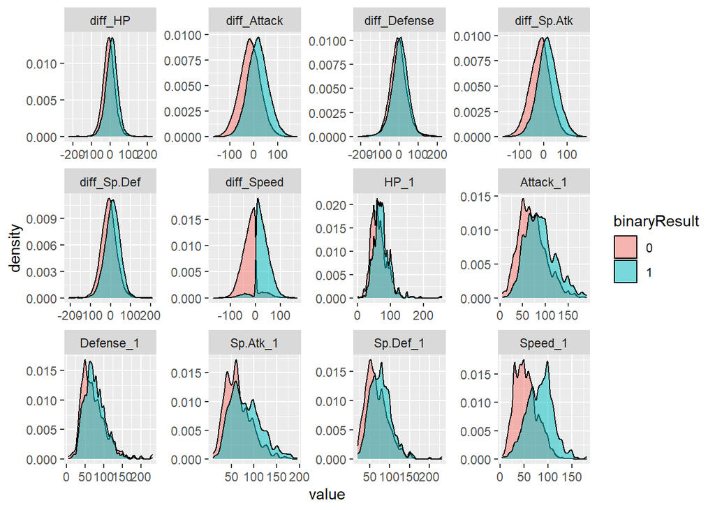

```r
# Generate multiple density chart
ggplot(mtxlong, aes(value, fill = factor(binaryResult))) + #create a canvas
  facet_wrap(~variable, scales = 'free', strip.position = 'top') + #create sequence of panels
  geom_density(alpha = 0.5) + #create density plot
  labs(fill = 'binaryResult') #rename the legend
```

首先，在創建模型之前，讓我們準備訓練和測試數據集。  
我們將從這50000行中分成兩部分。  
80％用於訓練數據，其餘為測試數據。

```r
result_1 <- predict(binary_tree_1, test_data, type = 'class')
table(result_1, test_label)
```

```
##         test_label
## result_1 Loss  Win
##     Loss 4960  204
##     Win   361 4475
```

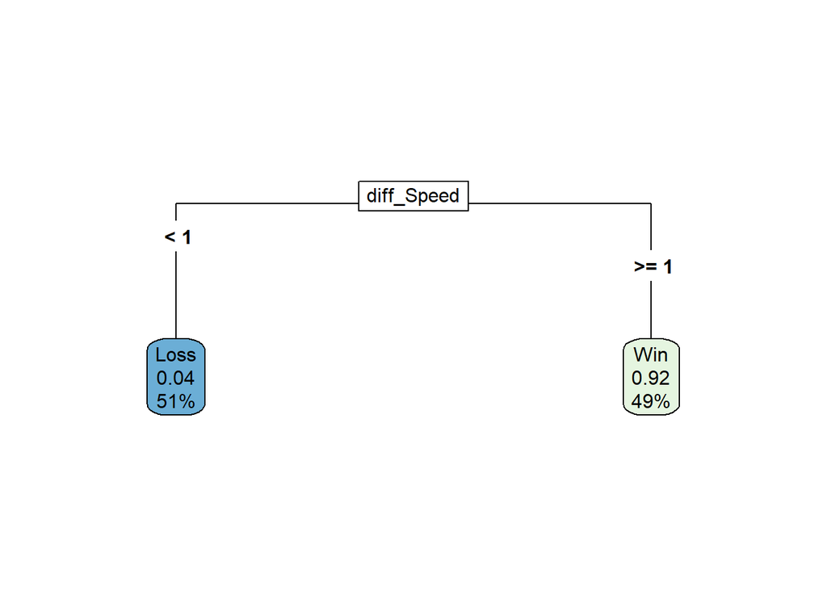

```r
rpart.plot(binary_tree_1, type = 5)
```

## Random Forest

```
##
## Call:
##  randomForest(formula = Result ~ ., data = train, type = "classification",      ntree = 500)
##                Type of random forest: classification
##                      Number of trees: 500
## No. of variables tried at each split: 5
##
##         OOB estimate of  error rate: 3.69%
## Confusion matrix:
##       Loss   Win class.error
## Loss 20210   868  0.04118038
## Win    607 18315  0.03207906
```

```
##       labels
##        Loss  Win
##   Loss 5099  222
##   Win   126 4553
```

## Conclusion and Discussion

1. 透過random forest 可以知道預測的準確度很高，很顯著的可以預測出贏的寶可夢和輸的寶可夢
2. diff.Sp & 第一隻寶可夢的速度可以區分戰鬥獲勝的寶可夢和戰鬥失敗的寶可夢
3. 隨機森林模型比只有一個節點的分類樹具有更高的準確性

參考資料 [kaggle 1](https://www.kaggle.com/jonathanbouchet/pokemon-battles/report) [kaggle 2](https://www.kaggle.com/ajisamudra/winner-in-pokemon-combat-prediction/notebook?select=tests.csv) [神奇寶貝百科](https://wiki.52poke.com/wiki/%E4%B8%BB%E9%A1%B5) [R Game 2020](https://chtsao.gitlab.io/krg20/)